# Introduction to Locally Weighted Regression

Before we get to locally weighted regression we will start with the basic assumption of linear regresion: $$ y = X ⋅ β + σϵ$$

Linear regrssion is the linear combination of observed outputs i.e. values of the dependent variable. Below we have the vectorized form of linear regression where $X^T$ are our observations:

$$ X^T y = X^T β + σX^Tϵ$$

We can solve for $β$ using the assumtion that $X^TX$ is an invertivle matrix.

$$β = (X^TX)^{-1} (X^Ty)-σ(X^TX)^{-1} X^T ϵ$$

Using this form we can take the expected value $\bar{β}$:

$$\bar{β} = (X^T)^{-1}(X^Ty)$$

Then the formula for predictions:

$$\hat{y} = X(X^TX)^{-1}(X^Ty)$$

For locally weighted regression we can multiply the equation for $\hat{y}$ with the diagonalized matrix of weights where the $i^{th}$ observation weight is on the diagonal.

$$diag(W(i))y = diag(W(i))X \cdot β + σ(W(i))ϵ$$

The equation is resolved to:

$$ diag(W(i))y = diag(W(i))X ⋅ \hat{β}$$

Each independent observation is a row in the matrix $X$. Each row has features (columns) $p$ such that every row is a vector in $\mathbb{R}^p$. For every $n$ observations we have $n$ weight vectors.

For locally weighted regression we have the formula:

$$\hat{y} = X(X^TWX)^{-1}(X^TWy)$$

The main takeaway is the predictions are the linear combination of the actual observed values of the dependent variable. In locally weighted regression, $\hat{y}$ is derived from different linear combinations of $y$.

# Let's explore these formulas with an example

Start by importing the nessessary packages and supporting configurations

```python
%matplotlib inline
%config InlineBackend.figure_format = 'retina'
import matplotlib.pyplot as plt
import matplotlib as mpl
mpl.rcParams['figure.dpi'] = 120
```

```python
import numpy as np
import pandas as pd
from math import ceil
from scipy import linalg
from scipy.interpolate import interp1d

from IPython.display import Image
from IPython.display import display
plt.style.use('seaborn-white')
```

For the example we will be using a dataset that describes different diamonds. The dataset will be limited to 5000 (of approx. 53000) samples to allow for faster processing times.

```python
# Load the data and sample 5000 examples
# Cut the first idex column out
data = pd.read_csv("/content/drive/MyDrive/Data Science/Data 441/LOWESS/diamonds.csv").iloc[:,1:].sample(5000)
data
```

|  | carat | cut | color | clarity | depth | table | price | x | y | z |
| --- | --- | --- | --- | --- | --- | --- | --- | --- | --- | --- |
| 6841 | 1.13 | Fair | J | SI1 | 64.9 | 55.0 | 4123 | 6.49 | 6.56 | 4.24 |
| 18148 | 1.01 | Premium | F | VS1 | 59.4 | 60.0 | 7353 | 6.50 | 6.46 | 3.85 |
| 15457 | 1.00 | Good | D | VS2 | 62.8 | 61.0 | 6189 | 6.31 | 6.34 | 3.97 |
| 18415 | 1.02 | Premium | F | VS1 | 61.9 | 58.0 | 7485 | 6.50 | 6.45 | 4.01 |
| 40242 | 0.37 | Ideal | E | VS1 | 61.2 | 56.0 | 1124 | 4.67 | 4.64 | 2.85 |
| ... | ... | ... | ... | ... | ... | ... | ... | ... | ... | ... |
| 48616 | 0.54 | Ideal | G | SI1 | 60.0 | 57.0 | 1999 | 5.31 | 5.36 | 3.20 |
| 45373 | 0.58 | Ideal | F | VS2 | 62.1 | 55.0 | 1666 | 5.33 | 5.37 | 3.32 |
| 34675 | 0.41 | Good | D | VS2 | 63.4 | 54.0 | 873 | 4.74 | 4.79 | 3.02 |
| 50682 | 0.76 | Ideal | H | SI2 | 63.0 | 56.0 | 2288 | 5.81 | 5.84 | 3.67 |
| 25633 | 1.51 | Premium | G | VS1 | 60.1 | 58.0 | 14507 | 7.48 | 7.45 | 4.49 |

5000 rows × 10 columns

Visualize the data

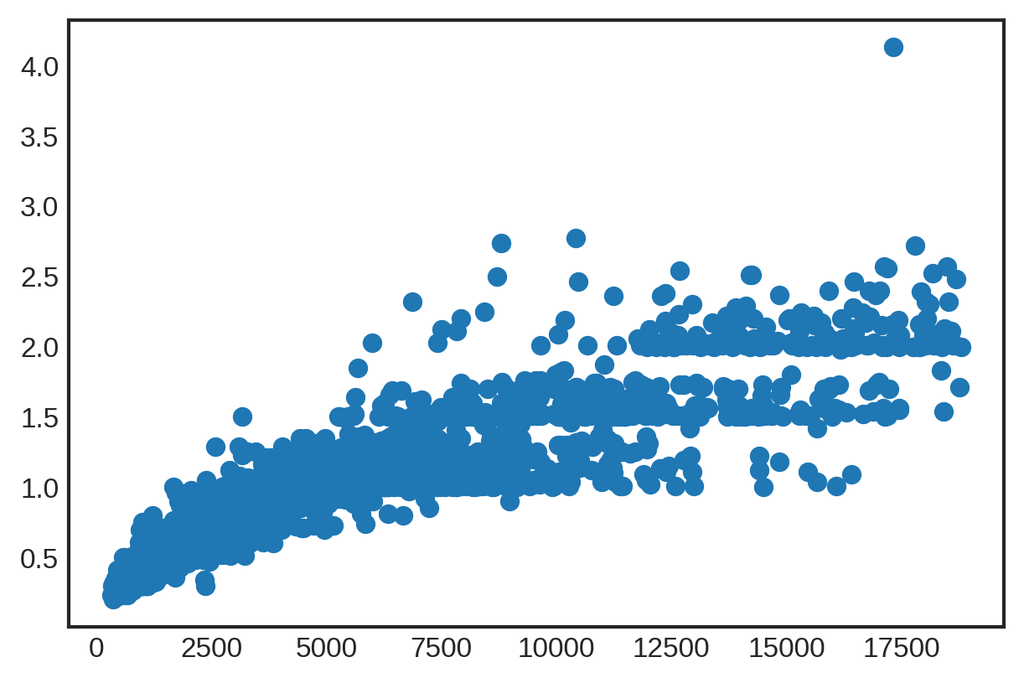

```python
X, y = data['price'].values, data['carat'].values
plt.scatter(X,y)
```

```python
data.sort_values(by='carat')
```

|  | carat | cut | color | clarity | depth | table | price | x | y | z |
| --- | --- | --- | --- | --- | --- | --- | --- | --- | --- | --- |
| 31599 | 0.20 | Ideal | E | VS2 | 62.2 | 57.0 | 367 | 3.76 | 3.73 | 2.33 |
| 47325 | 0.23 | Very Good | D | VVS2 | 62.6 | 58.0 | 530 | 3.89 | 3.94 | 2.45 |
| 40938 | 0.23 | Very Good | D | VVS2 | 59.6 | 61.0 | 499 | 3.99 | 4.03 | 2.39 |
| 42288 | 0.23 | Good | E | VVS2 | 62.2 | 60.0 | 505 | 3.90 | 3.94 | 2.44 |
| 43909 | 0.23 | Ideal | H | VS2 | 62.3 | 53.0 | 512 | 3.96 | 3.99 | 2.48 |
| ... | ... | ... | ... | ... | ... | ... | ... | ... | ... | ... |
| 27612 | 2.57 | Premium | J | SI1 | 63.0 | 58.0 | 18485 | 8.77 | 8.65 | 5.49 |
| 27302 | 2.72 | Ideal | J | SI2 | 62.1 | 56.0 | 17801 | 8.97 | 8.93 | 5.56 |
| 20462 | 2.74 | Fair | J | I1 | 64.9 | 61.0 | 8807 | 8.76 | 8.66 | 5.65 |
| 22399 | 2.77 | Premium | H | I1 | 62.6 | 62.0 | 10424 | 8.93 | 8.83 | 5.56 |
| 27130 | 4.13 | Fair | H | I1 | 64.8 | 61.0 | 17329 | 10.00 | 9.85 | 6.43 |

5000 rows × 10 columns

For the prediction we will be utilzing a Gaussian kernel in our lowess regression method.

```python
# Gaussian Kernel
def Gaussian(x):
  if len(x.shape)==1:
    d = np.abs(x)
  else:
    d = np.sqrt(np.sum(x**2,axis=1))
  return np.where(d>4,0,1/(np.sqrt(2*np.pi))*np.exp(-1/2*d**2))

def lowess_reg(x, y, xnew, kern, tau):
    # tau is our bandwidth hyperparameter
    n = len(x)
    yest = np.zeros(n)

    #Initialize weights from using the kernel function
    w = np.array([kern((x - x[i])/(2*tau)) for i in range(n)])

    #Looping through all x-points
    for i in range(n):
        weights = w[:, i]
        b = np.array([np.sum(weights * y), np.sum(weights * y * x)])
        A = np.array([[np.sum(weights), np.sum(weights * x)],
                    [np.sum(weights * x), np.sum(weights * x * x)]])
        #computes the least squares solution to the linear matrix
        theta, res, rnk, s = linalg.lstsq(A, b)
        yest[i] = theta[0] + theta[1] * x[i]
    f = interp1d(x, yest,fill_value='extrapolate')
    return f(xnew)
```

```python
xnew = np.arange(X.min(), X.max(), 10)
```

Below we will predict various sets of $\hat{y}$ values and visualize the fit against the actual test values.

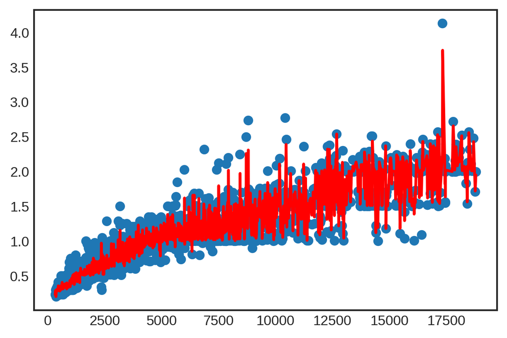

```python
yhat = lowess_reg(X,y, xnew, Gaussian, 0.5)
plt.scatter(X,y)
plt.plot(xnew, yhat,color='red',lw=2)
```

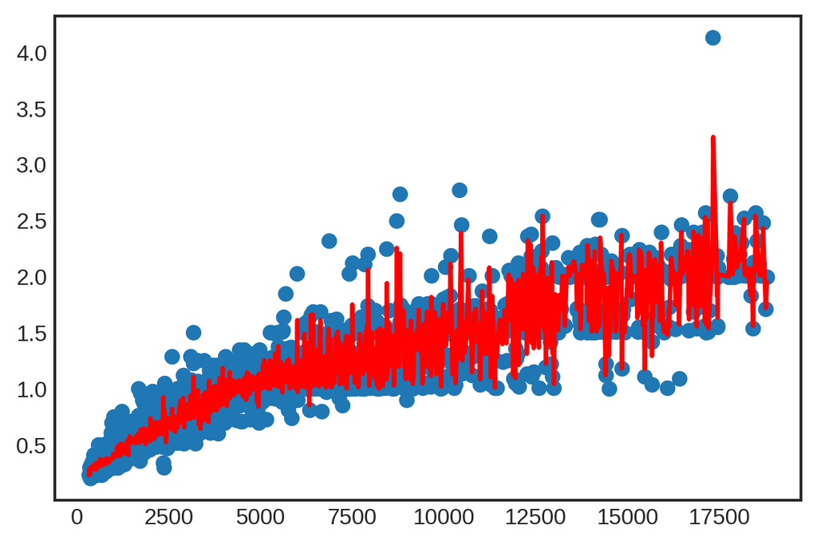

```python
yhat = lowess_reg(X,y, xnew, Gaussian, 1)
plt.scatter(X,y)
plt.plot(xnew, yhat,color='red',lw=2)
```

As we increase the value of our tau hyperparameter we can see that the fit of the line becomes more generalized, meaning it no longer directly intercepts a majority of the outlying observations.

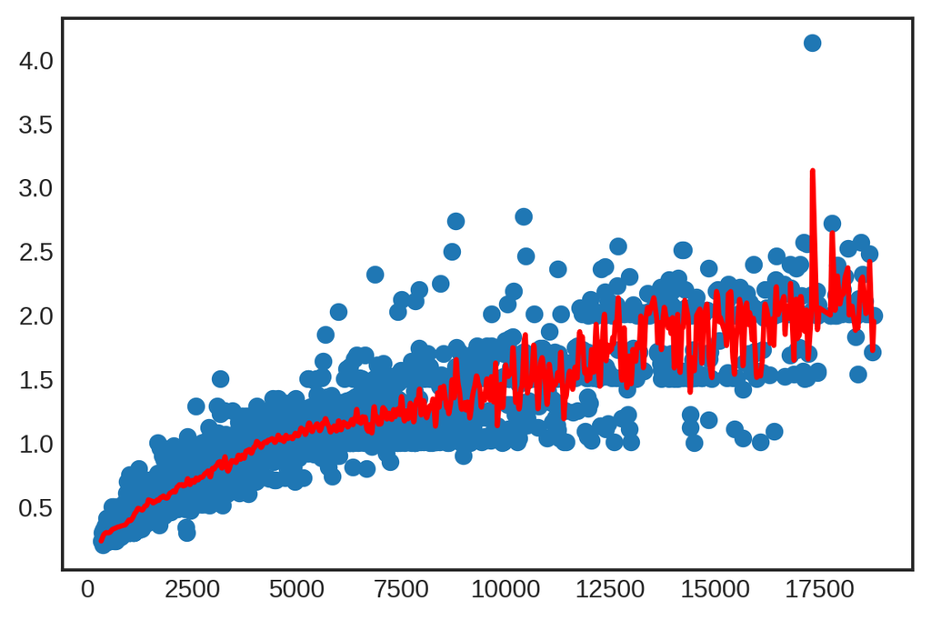

```python
yhat = lowess_reg(X,y, xnew, Gaussian, 10)
plt.scatter(X,y)
plt.plot(xnew, yhat,color='red',lw=2)
```

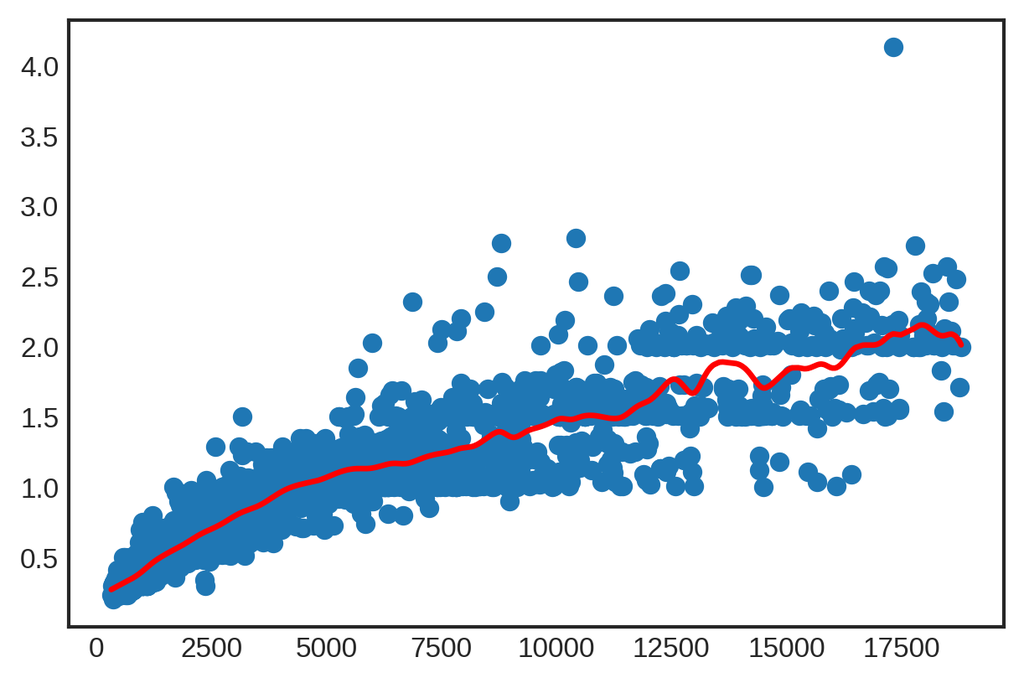

```python
yhat = lowess_reg(X,y, xnew, Gaussian, 100)
plt.scatter(X,y)
plt.plot(xnew, yhat,color='red',lw=2)
```